# Practising Qmd writing

Published

January 30, 2025

# Markdown

We want to use this document to practise writing with Markdown, and so this would mean using many of the nice formatting features that Markdown supports.

## One Piece to start off

To begin with, here are a handful of my favourite quotes from [One Piece](https://onepiece.fandom.com/wiki/One_Piece_Wiki):

> People’s dreams… have no end!

> — Marshall D. Teach

> Pirates are evil? The Marines are righteous? These terms have always changed throughout the course of history!

> — Donquixote Doflamingo

> Pirates are evil? The Marines are righteous? These terms have always changed throughout the course of history! Kids who have never seen peace and kids who have never seen war have different values! Those who stand at the top determine what’s wrong and what’s right! This very place is neutral ground! Justice will prevail, you say? But of course it will! Whoever wins this war becomes justice!

> — Donquixote Doflamingo

> Being strong isn’t about having power, but rather about one’s spirit.

> — Roronoa Zoro

> When does a man die? When he is hit by a bullet? No! When he suffers a disease? No! When he eats a soup made out of a poisonous mushroom? No! A man dies when he is forgotten!

> — Dr Hiluluk

## Moving on…

Fool me *once*, shame on you. Fool me **twice**, shame on me.

Fool me *three times*, hold up rewind, that’s not even possible…

The above line is from the song “That’s A Joke” by NF. (Image: Artwork for NF)

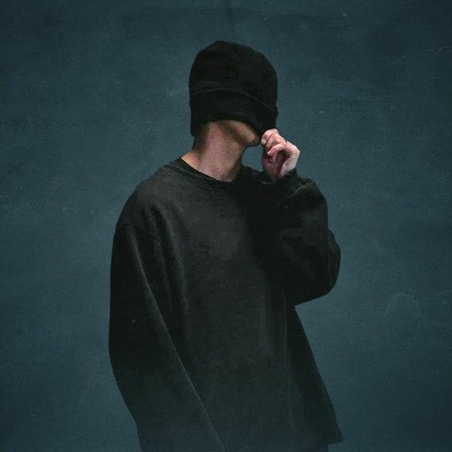

Underlining important points.

# Code chunks

```
[1] "Does using option within curly braces work?"
```

Will it allow figure captions to be below the figure?

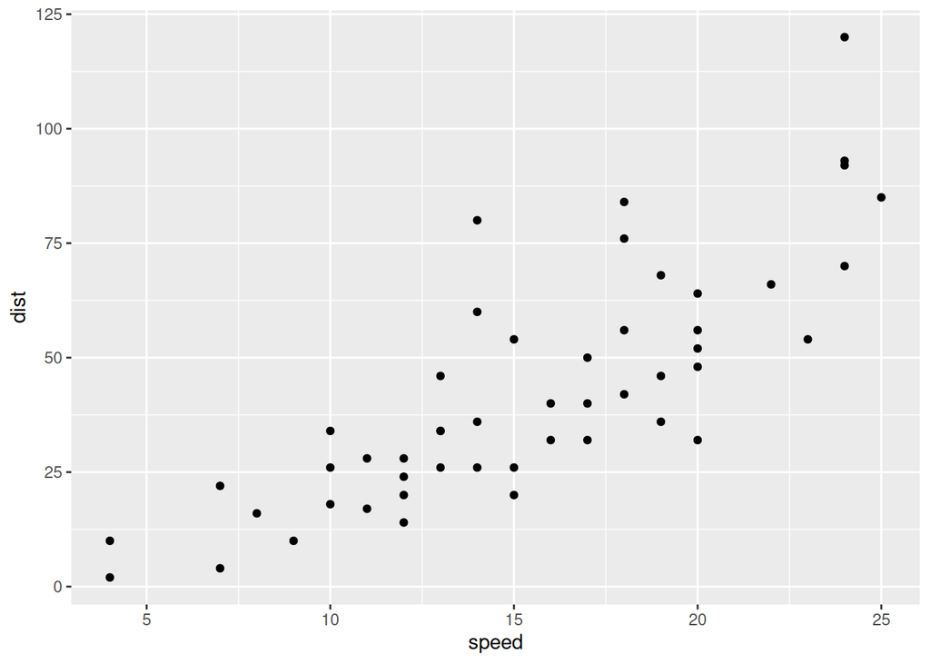

# Quarto Carpentry ([link](https://carpentries-incubator.github.io/reproducible-publications-quarto/))

Sourcing an external R script directly in the Qmd document, then pulling its output

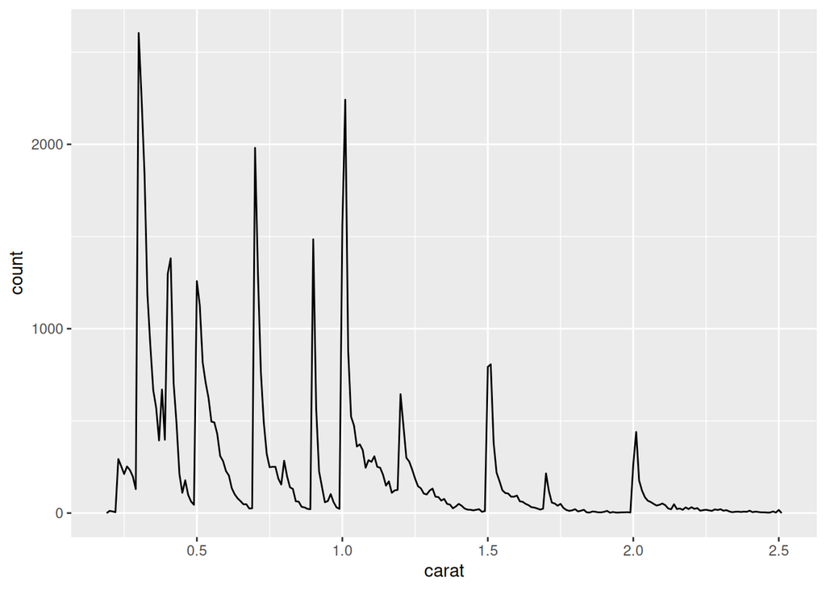

```r
source("w03_class2.R")

smaller_plot
```

# Final word…

> Man’s not hot

Hat-tip to [Anita Simha](https://anitasimha.com/) for the idea.

[figure not shown]